# Kgotso Botsi

Mr.Botsi

5/4/2021

```r
rm(list=ls())
df <- readxl::read_xlsx("./transactionsxls.xlsx")
df$Ymd <- lubridate::dmy_hms(df$Date)
df$Ymd <- as.Date(df$Ymd)

summary(df$Duration)
```

```
##    Min. 1st Qu.  Median    Mean 3rd Qu.    Max.
##   3.520   4.800   6.060   6.048   7.310   8.550
```

#### (1)What distribution best describes the transaction duration for the entire data set?

- Answer: Uniform Distribution

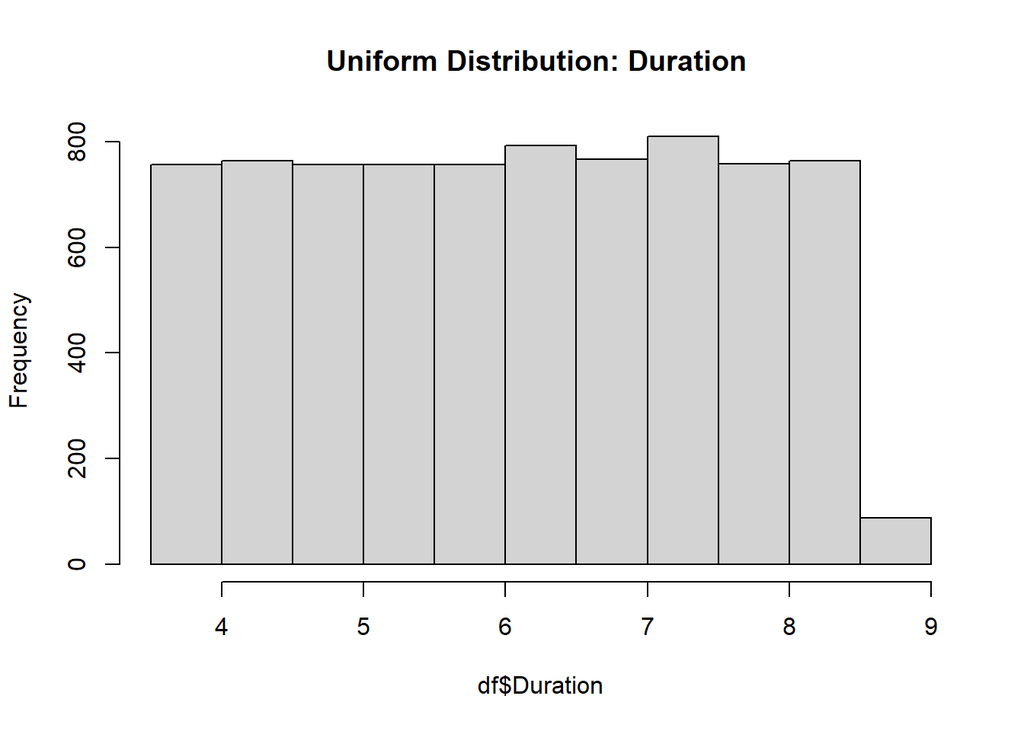

```r
hist(df$Duration, main = "Uniform Distribution: Duration ")
```

#### (3)Calculate the 99% conidence limits for the mean of the transaction duration of the entire data set. Round

your answers to three decimal places. For example, 1.234.

- Lower Limit:6.005
- Upper Limit6.09

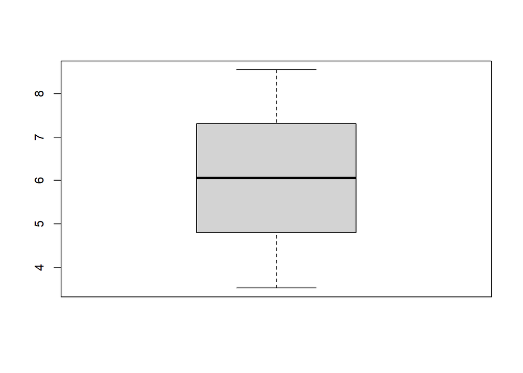

```r
boxplot(df$Duration)
```

```r
t.test(df$Duration,conf.level = 0.99)
```

```
##
##  One Sample t-test
##
## data:  df$Duration
## t = 366.85, df = 7768, p-value < 2.2e-16
## alternative hypothesis: true mean is not equal to 0
## 99 percent confidence interval:
##  6.005289 6.090239
## sample estimates:
## mean of x
##  6.047764
```

#### (4) You read a discussion on the third year WhatsApp group where a student claims the answer to question 2. was a uniform distribution. Do you believe the claim? Yes or No

Answer: Yes it is a uniform distribution

#### (5)Motivate your answer in question 4 using a x^2 test with 6 breaks. That is, use the breaks=6 argument for

your histogram.

```r
chisq.test(df$Duration,  correct = TRUE)
```

```
##
##  Chi-squared test for given probabilities
##
## data:  df$Duration
## X-squared = 2712, df = 7768, p-value = 1
```

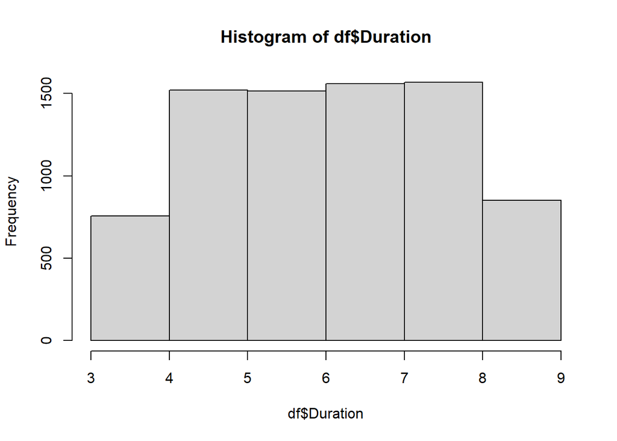

```r
hist(df$Duration,breaks = 6)
```

#### (6) What is the total number of entries through the northern turnstile?

```r
table(df$Type,df$Turnstile)
```

```
##
##            C    N    S
##   entry 1944  660 1235
##   exit  1936  691 1303
```

*Answer:660

#### (7)Some students attribute the lower usage of the northern turnstile for entries to an error-prone card reader. Do you agree with them that the proportion of first-time successes is a function of the gate?

```r
table(df$Turnstile,df$Success)
```

```
##
##     false true
##   C   185 3695
##   N    57 1294
##   S   138 2400
```

```r
TAB <- table(df$Turnstile,df$Success)
prop.table(TAB)
```

```
##
##           false        true
##   C 0.023812588 0.475608186
##   N 0.007336852 0.166559403
##   S 0.017762904 0.308920067
```

```r
tab_df <- as.data.frame(TAB)
```

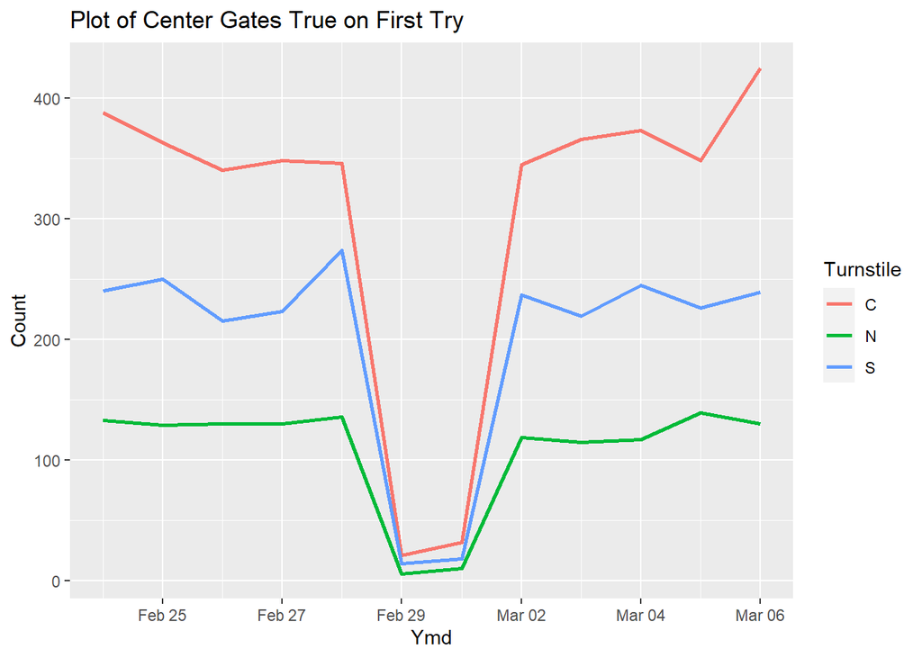

```r
df %>% filter(Success=="true") %>%
  group_by(Ymd,Turnstile) %>% summarise(Count = n()) %>%
ggplot() + geom_line(aes(x=Ymd,y=Count,col=Turnstile),lwd=1) +
  labs(title="Plot of Center Gates True on First Try")
```

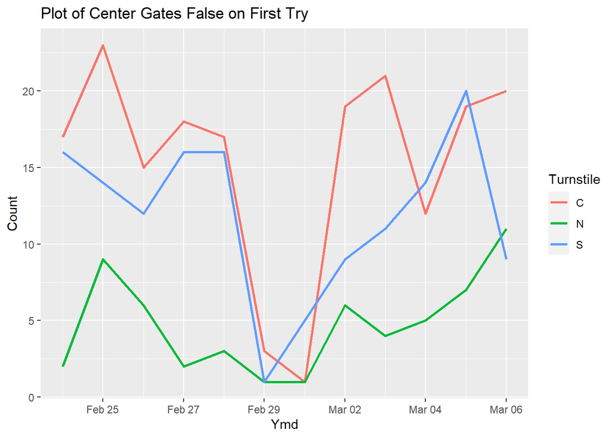

```r
df %>% filter(Success=="false") %>%
  group_by(Ymd,Turnstile) %>% summarise(Count = n()) %>%
ggplot() + geom_line(aes(x=Ymd,y=Count,col=Turnstile),lwd=1) +
  labs(title="Plot of Center Gates False on First Try")
```

#### (9) Consider students leaving the campus on Wednesday, 4 March 2020 through the center gate, C. What

proportion of the day’s transactions does it represent? Round your answer to four decimal places. For example, if you believe it is 12.34%, give your answer as 0.1234.

#### (10). What is the arrival rate, in entries per hour, on weekdays between 08:00 and 09:00? Round your answer

to one decimal place. For example, if you believe it is 12.34, give your answer as 12.3.

#### (11) What distribution should the arrival rate of question 10 typically follow?

#### Submit your supporting code (R or RMarkdown document) as a single file, using your student number as

the filename. For example, 01234567.R or 01234567.Rmd.

*File Name:18090533.Rmd.